# <실습>

## 카이제곱 검정의 해석

공식) 카이 제곱 검증 과정에서 카이 제곱을 계산하는 법, 공식

(관찰빈도 0) 에서 기대빈도 E를 뺀 후 그것을 제곱해서 (기대빈도 E) 로 나눈 값을 모두 합친 값이다. => Pvalue 를 계산

### 카이제곱검증 예문

- 적합도 검정과 독립 검정으로 나뉜다.
- 적합도 검정(Goodness of fit test) : 관측된 데이터가 예측한 분포를 따르는지 검정하는 방법이다.
- 독립성 검정(Test of independence): 관측값들이 다수의 인자들에 의해 분할 되어 있는 경우 그 인자들의 관찰 값에 영향을 주고 있는지 아닌지를 검정하는 방법.

### 적합도 검정(Goodness of fit test) 예문

- 아래 표는 주사위를 60번 던져서 각각 나온 관측값과 기대횟수를 작성한 표이다.
- 각각 1/6로 나와야 하기 때문에 기대값은 각 횟수당 10이 된다.

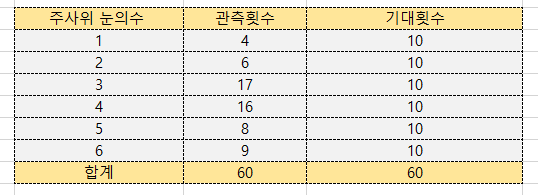

```python
import pandas as pd
from scipy import stats
from numpy import mean
#귀무가설(H0) : 두 변수는 연관성이 없다. 적합하다.
#대립가설(H1) : 두 변수는 연산성이 있다. 적합하지 않다.

data1 = [4,6,17,16,8,9]
print('주사위 던진 횟수 : ',sum(data1))
```

```
주사위 던진 횟수 :  60
```

```python
import pandas as pd
from scipy import stats
from numpy import mean
#귀무가설 : data1과 data2는 차이가 없다.
#대립가설 : data1과 data2는 차이가 있다.
data1 = [4,6,17,16,8,9]
data2 = [10,10,10,10,10,10]
# 검정통계량과 p-value
chis = stats.chisquare(data1, data2)
chis
# p-value가 0.05보다 작으므로 95% 신뢰수준 하에서 유의한 관계가 있다.
```

```
Power_divergenceResult(statistic=14.200000000000001, pvalue=0.014387678176921308)
```

```python
# 다른 관측값
import pandas as pd
from scipy import stats
from numpy import mean
#귀무가설 : data1과 data2는 차이가 없다.
#대립가설 : data1과 data2는 차이가 있다.
data1 = [16,5,9,7,6,17]
data2 = [10,10,10,10,10,10]
# 검정통계량과 p-value
chis = stats.chisquare(data1, data2)
statistic,pvalue = chis

if pvalue < 0.05:
    print("대립가설 채택")
else:
    print("귀무가설 채택")
```

```
대립가설 채택
```

### P-value < 0.05 = 대립가설

- 내가 주장하고 싶은 것은 대립가설인데 귀무가설은 대립가설에 반대되는 가설이다.
- p-value를 기준으로 0.05 보다 작으면95% 신뢰수준하에서 유의한 관계가 있다 그래서 대립가설 채택
- 즉 내가 주장하고 싶은 가설을 채택한다.

## 연습문제1)

### 다음 표는 완두콩의 잡종의 분류에 대한 관측도수와 기대치이다.

### 이 데이터는 유전의 이론적으로 모형에 부합된다고 할 수 있는가? (유의수준 : 0.05)

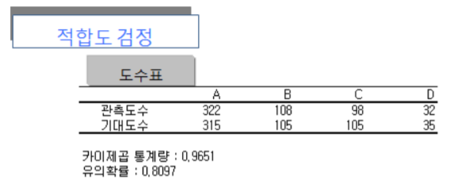

```python
# 다음 문제를 보고 적합도를 검정 해내시오.
# 이 데이터는 유전 모형에 부합 될 수있는가?

# 정답) 귀무가설 : 유전이론모형에 부합한다
# 대립가설 : 유전이론 모형에 부합하지 않는다.
```

[output not shown]

## 연습문제2)

한 교양과목을 강의하고 있는 P교수는 수강생들의 학년 분포가 모든 학년에 대해 균일한지 여부를 알아보고자한다.

이를 위해 지난 학기 수강자 171명의 학년 분포를 조사하여 아래 표와 같은 결과를 얻었다.

카이제곱 적합도 검정을 사용하여 이 문제를 풀어보시오(유의수준 0.05).

가설검정을 위한 통계량 중에 각 학년별 기대빈도는 전체 표본의 수 171명에 각 범주(학년)의 기대비율(25%)를 곱해서 구한다.

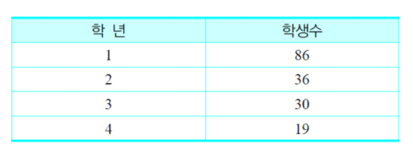

X (171 x 0.25 ) = 42.75

```python
1/4
```

```
0.25
```

풀이) 기대 비율이 25% 인 이유는 => 1.00 을 기준으로 1/4 = 0.25

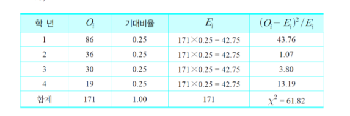

1) 가설 수립 :

[output not shown]

```python
대립가설, 귀무가설 중에 어떤것이 채택이 되는가?
```

## 연습문제3)

Kosmo 항공사에서는 과거 항공권 판매 자료를 통하여 유럽지역 항공권 구매자의 연령 분포가 다음과 같다. <연령범주>

- 20대 이하 : 8%
- 3~40대 : 47%
- 50대 : 34%
- 60대 이상 : 11%

Kosmo 항공사는 최근 새롭게 확장 된 동남아지역으로 고객들이 증가함에 따라 기존의 영업정책을 수정 해야 하는지를 검토하고 있다.

이에 Kosmo 항공사에서는 동남아지역 항공권 구매자의 연령분포가 유럽지역의 경우와 같은지를 알고 싶어 한다.

이를 검정하기 위해서 동남아지역 항공권 구매자 207명을 무작위로 조사한 결과, 아래 표와 같은 연령 분포를 얻었다.

카이제곱 적합도 검정을 사용해서 이 문제를 풀어 보시오 (유의 수준 0.05)

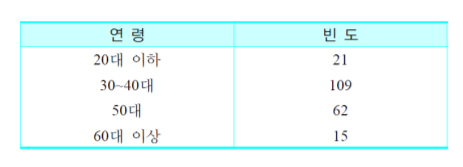

## 풀이

### 1) 가설을 수립한다.

귀무가설(H0) :

대립가설(H1) :

### 2) 가설검정을 위한 통계량을 구한다.

### 연령범주별 기대빈도는 전체 표본의 수 207명에 각 연령범주의 기대 비율을 곱하여 구한다.

[output not shown]

```python
############## 연습문제 끝
```

- 독립성 검정(Test of independence): 관측값들이 다수의 인자들에 의해 분할 되어 있는 경우 그 인자들의 관찰 값에 영향을 주고 있는지 아닌지를 검정하는 방법.

  : 여러 범주를 가지는 두 개의 변수가 서로 독립적인지 또는 관련이 있는지를 분석하는 기법

```python
from scipy import stats
obs = np.array([[5, 15], [10, 20]])
#카이제곱 통계량, p-value, 자유도 등을 Return
statistic,pvalue,_,_ =stats.chi2_contingency(obs)
print(statistic)
print(pvalue)
```

```
0.0992063492063492
0.7527841326498471
```

```python
# 독립성 검정(Test of independence) => Sample A와 Sample B의 전환율 차이가 있는지 카이제곱 검정
import matplotlib.pyplot as plt
import matplotlib
from scipy.stats import norm
import matplotlib.font_manager as fm

# 두 개의 광고 서비스를 통해 각각 유입된 사용자들의 이용률을 아래와 같이 얻었다고 하자.
# 테스트 데이터. [지속 이용 전환 , 이탈 수]
# 유입사용자수 : A : 205 , B : 290
# 귀무가설 : 모집단 Sample A와 모집단 Sample B의 지속 이용 전환율은 다르지 않다
# 대립가설 : 모집단 Sample A와 모집단 Sample B의 지속 이용 전환율은 다르다.
data1 = np.array([40,165])
data2 = np.array([62,228])


print('Sample A: 유입사용자수={}, 지속이용 사용자수={}, 지속이용전환율(mean)={:.3f}'.format(np.sum(data1), data1[0], data1[0]/np.sum(data1)))
print('Sample B: 유입사용자수={}, 지속이용 사용자수={},  지속이용전환율(mean)={:.3f}'.format(np.sum(data2), data2[0], data2[0]/np.sum(data2)))
```

```
Sample A: 유입사용자수=205, 지속이용 사용자수=40, 지속이용전환율(mean)=0.195
Sample B: 유입사용자수=290, 지속이용 사용자수=62,  지속이용전환율(mean)=0.214
```

```python
# 유의수준 0.05보다 크므로 귀무가설(Sample A와 Sample B 모집단은 지속 이용 전환율이 같다)을 기각할 수 없다.
# 즉, 모집단 Sample A와 모집단 Sample B의 지속 이용 전환율은 다르지 않다라고 결론 지을 수 있다.
statistic,pvalue,_,_ =stats.chi2_contingency([a,b])
print(statistic)
print(pvalue)
```

```
0.15451791002162868
0.694254736449269
```